# Model fitting script for meta-analysis

Justin Tiano, Emil De Borger

2022-10-06

# 1 Summary

In this version rows with SD = 0 are kept, and resulting weights are manually assigned to be able to keep these rows in further analysis.

This script is used to run statistics on the meta-analyis effect size data. First data is loaded and some variables are re-factored (e.g. slicedepth). Focusing on organic carbon measures and chl a as variables of interest, we first assess the significance of the effects individual predictor variables (factors and continuous) may have on the log response ratios found in different studies. Then, we determine the best predictive models for the different sets of observations using two methodologies: stepwise model selection and multimodel predictions. Throughout this data exploration the observations on OC and chl are divided into different subsets: the immediate response (=< 24 h after disturbance), recovery (all known times) and all available data (contains observations where time since last disturbance is unknown).

Throughout this document some code is shown, some not, for legibility purposes.

First, wilcoxon tests on all data subsets indicate a statistically significant difference of the mean lnRR to 0, with estimates all below 0 (ranging from -0.134 to -0.234). Meaning that, throughout our dataset, the response to trawling is a decrease in TOC and Chl a.

Below, the significant/non-significant predictors are mentioned for each tested subset of data. The full results can be found further below.

OC recovery

- rOC: No statistical significant differences in means of factor levels.
- rOCcont: Significant linear correlation with current velocity, hours fished, surface pp.
- Best model stepwise: current velocity + slice-depth.
- Best model multimodel: current velocity.

OC all data

- aOC: No statistically significant differences in means of factor levels.
- aOCcont: Significant linear correlation with current velocity, hours fished, water depth, surface pp. These predictors (barring hours fished) are also significantly correlated, cannot use all in model fitting.
- Best model stepwise: current velocity, habitat type, water depth, bottom water O2.
- Best model multimodel: urrent velocity, habitat type, water depth, bottom water O2, season.

CHshort

- sCH: Significant difference in means for season: higher lnRR in winter.
- sCHcont: significant variable is surface pp.
- Best model stepwise: current velocity + surface pp + hours fished.
- Best model multimodel: water depth + surface pp + hours fished.

CH recovery

- rCH: Significant factor effects for slice depth, historically fished, and habitat type.
- rCHcont: Significant linear correlation with current velocity, surface pp, O2 bottom water, distance to shore.
- Best model stepwise: slice-depth + water depth + bottom water O2 + surface pp + time since trawling.
- Best model multimodel: time since trawling (low r2: 8.15%, 2nd best model selected 27%).
- 2nd model multimodel: habitat type + water depth + surface pp + bottom water O2 + distance to shore.

CH all data

- aCH: Significant factor effects for slice depth and habitat type.
- aCHcont: Significant linear correlation with current velocity and surface pp.
- Best model stepwise: slice-depth + water depth + habitat type + current velocity + water depth + O2 bottom water.
- Best model multimodel: slice-depth + water depth + habitat type + current velocity + O2 bottom water

# 2 Read data / subsetting

## 2.1 Read and change title

Input functions for plots and calculations - shows edits to the original effect size dataframe (df) which includes combining certain categories, and fixing details for individual studies.

```r
# load("../r_objects/Exp-Obs.rda")
# get(load("../dataset/dataset.rdata"))
load("../r_objects/Exp-Obs_041122.rda")

# Edit column names for to facilitate modelling.

colnames(df)[colnames(df) == "Response.variable"]                     <- "respvar"
colnames(df)[colnames(df) == "Sample.core.depth.slice"]               <- "slicedepth"
colnames(df)[colnames(df) == "Study.type"]                            <- "stype"
colnames(df)[colnames(df) == "Harmonized_study.type"]                 <- "hstype"
colnames(df)[colnames(df) == "Water.depth..m."]                       <- "watdepth"
colnames(df)[colnames(df) == "Trawling.effort_numerical_harmonized"]  <- "heffortnum"
colnames(df)[colnames(df) == "Trawling_effort_GFW"]                   <- "effortGFW"
colnames(df)[colnames(df) == "Model_Chl_bottom..mg.m3"]               <- "chlabot"
colnames(df)[colnames(df) == "Model_Current_velocity..m.s."]          <- "cvel"
colnames(df)[colnames(df) == "Model_Dissolved_Oxygen..mol.m3."]       <- "O2bot"
colnames(df)[colnames(df) == "Model_NO3_bottom..mol.m3."]             <- "nitbot"
colnames(df)[colnames(df) == "Model_PO4_bottom..mol.m3."]             <- "phosbot"
colnames(df)[colnames(df) == "Model_Sal_bottom"]                      <- "salbot"
colnames(df)[colnames(df) == "Model_Silicate_bottom..mol.m3."]        <- "silbot"
colnames(df)[colnames(df) == "Model_Temp_bottom"]                     <- "tempbot"
colnames(df)[colnames(df) == "Model_NPP_surface..g.m3.day."]          <- "nppsurf"
colnames(df)[colnames(df) == "dist_shore..m."]                        <- "shoredist"
colnames(df)[colnames(df) == "Time.since.trawl..days."]               <- "timesincetrawl"
colnames(df)[colnames(df) == "Time.since.first.disturbance..years."]  <- "timefirstdist"
colnames(df)[colnames(df) == "Habitat.type_harmonized"]               <- "hhabtype"
colnames(df)[colnames(df) == "Seasonality_harmonized"]                <- "hseason"
colnames(df)[colnames(df) == "Trawling.gear.type_harmonized"]         <- "gear"
colnames(df)[colnames(df) == "Historically.fished"]                   <- "histfished"
colnames(df)[colnames(df) == "Trawling.effort_categorical"]           <- "effortcat"
colnames(df)[colnames(df) == "Trawling.effort_units_harmonized"]      <- "heffortunits"
colnames(df)[colnames(df) == "Control_historically_trawled"]          <- "CTRLhisttrawled"
```

## 2.2 Refactoring slicedepth

```r
# Refactoring data: combining categories

## Depth slices --> I think there's still something wrong here.
## I'm going with 0-1, 1-2, 2-5, 5-10, 10+ as classes for lowest common denominator.
## For the categories 0-x it is more difficult but al least the number of categories has been
## brought down drastically already.
df$sslicedepth <- df$slicedepth
df$sslicedepth[df$sslicedepth=="0-0.3"]   = "0-1"
df$sslicedepth[df$sslicedepth=="0-0.5"]   = "0-1"
df$sslicedepth[df$sslicedepth=="0-1"]     = "0-1"
df$sslicedepth[df$sslicedepth=="0.5-1"]   = "0-1"
df$sslicedepth[df$sslicedepth=="Surface"] = "0-1"

df$sslicedepth[df$sslicedepth=="1-1.5"] = "1-2"
df$sslicedepth[df$sslicedepth=="1.5-2"] = "1-2"
df$sslicedepth[df$sslicedepth=="1-3"]   = "1-2" #ranks

df$sslicedepth[df$sslicedepth=="2-2.5"] = "2-5"
df$sslicedepth[df$sslicedepth=="2.5-3"] = "2-5"
df$sslicedepth[df$sslicedepth=="2-3"]   = "2-5"
df$sslicedepth[df$sslicedepth=="3-4"]   = "2-5"
df$sslicedepth[df$sslicedepth=="4-5"]   = "2-5"
df$sslicedepth[df$sslicedepth=="3-5"]   = "2-5"
df$sslicedepth[df$sslicedepth=="3-3.5"] = "2-5"
df$sslicedepth[df$sslicedepth=="3.5-4"] = "2-5"
df$sslicedepth[df$sslicedepth=="4-4.5"] = "2-5"
df$sslicedepth[df$sslicedepth=="4.5-5"] = "2-5"
df$sslicedepth[df$sslicedepth=="2-4"]   = "2-5"
df$sslicedepth[df$sslicedepth=="4-6"]   = "2-5"

df$sslicedepth[df$sslicedepth=="5-6"]  = "5-10"
df$sslicedepth[df$sslicedepth=="6-7"]  = "5-10"
df$sslicedepth[df$sslicedepth=="7-8"]  = "5-10"
df$sslicedepth[df$sslicedepth=="8-9"]  = "5-10"
df$sslicedepth[df$sslicedepth=="9-10"] = "5-10"
df$sslicedepth[df$sslicedepth=="5-7"]  = "5-10"
df$sslicedepth[df$sslicedepth=="7-9"]  = "5-10"
df$sslicedepth[df$sslicedepth=="7-10"] = "5-10"
df$sslicedepth[df$sslicedepth=="5-10"] = "5-10"
df$sslicedepth[df$sslicedepth=="4-8"]  = "5-10"
df$sslicedepth[df$sslicedepth=="6-10"] = "5-10"

df$sslicedepth[df$sslicedepth=="10-11"] = "10+"
df$sslicedepth[df$sslicedepth=="11-12"] = "10+"
df$sslicedepth[df$sslicedepth=="12-13"] = "10+"
df$sslicedepth[df$sslicedepth=="13-14"] = "10+"
df$sslicedepth[df$sslicedepth=="14-15"] = "10+"
df$sslicedepth[df$sslicedepth=="15-16"] = "10+"
df$sslicedepth[df$sslicedepth=="16-17"] = "10+"
df$sslicedepth[df$sslicedepth=="17-18"] = "10+"
df$sslicedepth[df$sslicedepth=="18-19"] = "10+"
df$sslicedepth[df$sslicedepth=="19-20"] = "10+"
df$sslicedepth[df$sslicedepth=="20-21"] = "10+"
df$sslicedepth[df$sslicedepth=="21-22"] = "10+"
df$sslicedepth[df$sslicedepth=="22-23"] = "10+"
df$sslicedepth[df$sslicedepth=="23-24"] = "10+"
df$sslicedepth[df$sslicedepth=="24-25"] = "10+"
df$sslicedepth[df$sslicedepth=="25-26"] = "10+"
df$sslicedepth[df$sslicedepth=="26-27"] = "10+"
df$sslicedepth[df$sslicedepth=="27-28"] = "10+"
df$sslicedepth[df$sslicedepth=="28-29"] = "10+"
df$sslicedepth[df$sslicedepth=="29-30"] = "10+"
df$sslicedepth[df$sslicedepth=="30-31"] = "10+"
df$sslicedepth[df$sslicedepth=="31-32"] = "10+"
df$sslicedepth[df$sslicedepth=="32-33"] = "10+"
df$sslicedepth[df$sslicedepth=="33-34"] = "10+"
df$sslicedepth[df$sslicedepth=="34-35"] = "10+"
df$sslicedepth[df$sslicedepth=="35-36"] = "10+"
df$sslicedepth[df$sslicedepth=="36-37"] = "10+"
df$sslicedepth[df$sslicedepth=="37-38"] = "10+"
df$sslicedepth[df$sslicedepth=="38-39"] = "10+"
df$sslicedepth[df$sslicedepth=="39-40"] = "10+"
df$sslicedepth[df$sslicedepth=="40-41"] = "10+"
df$sslicedepth[df$sslicedepth=="41-42"] = "10+"
df$sslicedepth[df$sslicedepth=="42-43"] = "10+"
df$sslicedepth[df$sslicedepth=="10-12"] = "10+"
df$sslicedepth[df$sslicedepth=="10-15"] = "10+"
df$sslicedepth[df$sslicedepth=="15-20"] = "10+"

df$sslicedepth[df$sslicedepth=="Grab sample"] = "0-5"
df$sslicedepth[df$sslicedepth=="Full core"]   = "0-5"

# Other edits (Sarah suggests not removing these).
# df = df[-c(659:670),]  # remove 1cm sediment samples from Tiano et al 2022 as 1-10 cm used for analysis
```

## 2.3 Subsetting

We subset the dataset:

- short: immediate trawling impact measurements: =< 1 day impact assessment.
- recovery: trawling + recovery for all known trawling times.
- All: all samples
- UN: unknown sampling time since trawl ==> Not used in the end.

The logic of subsetting is to facilitate making regressions with different known times.

- Short term is considered as assessed within 1 day of disturbing.
- Recovery is a more long-term assessment.
- all is all data, and in this dataset we do not focus on recovery time.

Retrieve data (to skip above steps)

## 2.4 Summary statistics

```r
a <- wilcox.test(OCshort$lnRR, mu = 0, conf.int = TRUE)
b <- wilcox.test(OCrec$lnRR, mu = 0, conf.int = TRUE)
c <- wilcox.test(OCall$lnRR, mu = 0, conf.int = TRUE)

d <- wilcox.test(CHshort$lnRR, mu = 0, conf.int = TRUE)
e <- wilcox.test(CHrec$lnRR, mu = 0, conf.int = TRUE)
f <- wilcox.test(CHall$lnRR, mu = 0, conf.int = TRUE)

wttable <- data.frame("difference means" = c(a$estimate,b$estimate, c$estimate, d$estimate, e$estimate, f$estimate),
                      "pvalue" = c(a$p.value, b$p.value, c$p.value, d$p.value, e$p.value, f$p.value))

row.names(wttable) <- c("OC-short", "OC-recovery", "OC-all",
                        "CH-short", "CH-recovery", "CH-all")

knitr::kable(wttable, caption = "Results Wilcox test")
```

Results Wilcox test

|  | difference.means | pvalue |
| --- | --- | --- |
| OC-short | -0.1375264 | 4.7e-05 |
| OC-recovery | -0.1376721 | 1.0e-07 |
| OC-all | -0.1632601 | 0.0e+00 |
| CH-short | -0.2343957 | 3.4e-06 |
| CH-recovery | -0.1605023 | 1.1e-06 |
| CH-all | -0.1342354 | 1.1e-05 |

Note on use of rma.uni with the full dataset:

- Restricted maximum likelihood estimator (REML) is used as it is apparently the most robust estimator for our type of data, and it can deal with our instances where VarLnRR = 0.
  - However it gives a warning, and it cannot perform the QE test or compute I^2 and H^2.
- We stick to a weighted analysis, given previous steps taken to ensure a weight is available.
  - This is the default so no need to specify, however I provide the weights because otherwise they are calculated again without the corrections in 2_EF_calculation.

Factors: - Habitat type - Historically fished - Season - Slice depth

Continuous - Water depth - Fishing effort (h) - Current velocity - Salinity bottom - Oxygen bottom - Time since trawling

Fitted models overview

# 3 SHORT TERM OC

## 3.1 Individual variables

| Mods | Rsquared | Pvalue |
| --- | --- | --- |
| Slice depth | 8.8871831 | 0.4659583 |
| Historically fished | 0.8505775 | 0.5307506 |
| Season | 0.9343762 | 0.6536957 |
| Sediment | 5.0027461 | 0.0438344 |

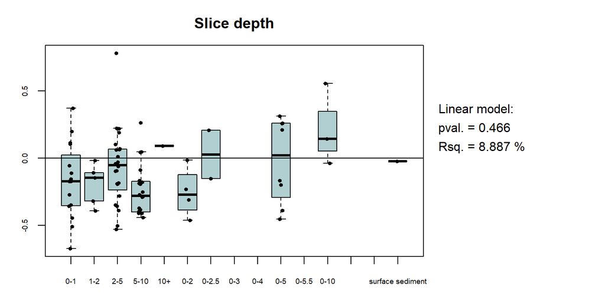

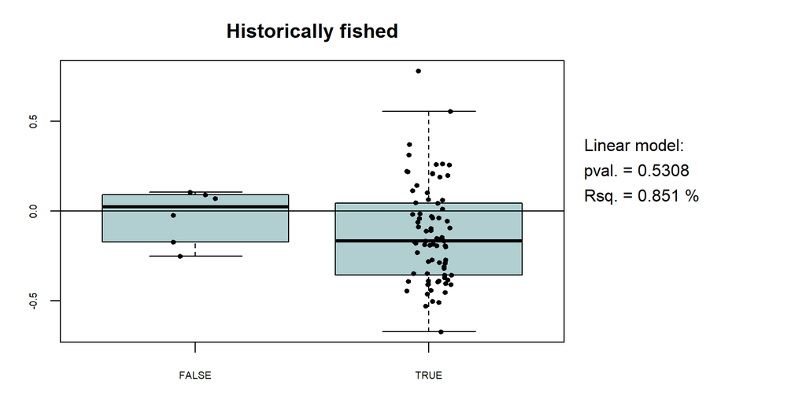

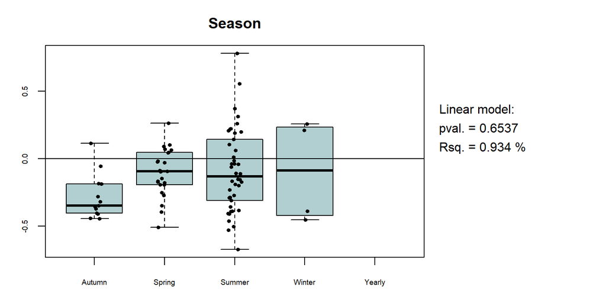

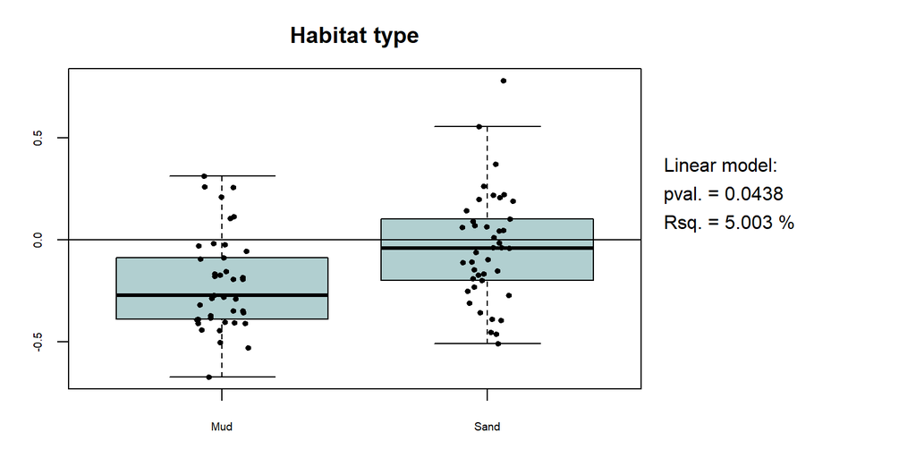

## 3.2 Continuous variables

| Mods | Rsquared | Pvalue |
| --- | --- | --- |
| Current velocity | 26.011224 | 0.0291809 |
| Hours fished | 13.723416 | 0.1869533 |
| Depth | 20.676006 | 0.6103524 |
| NPP surf. | 11.188113 | 0.0636054 |
| O2 bottom | 13.733671 | 0.4383260 |
| Dist. shore | 4.033551 | 0.6187014 |

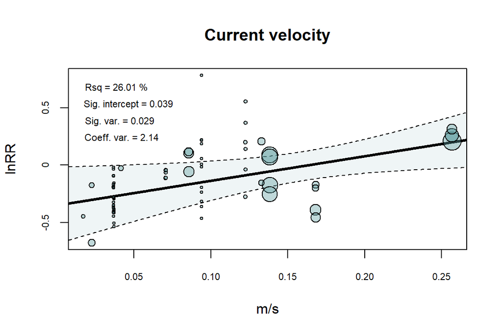

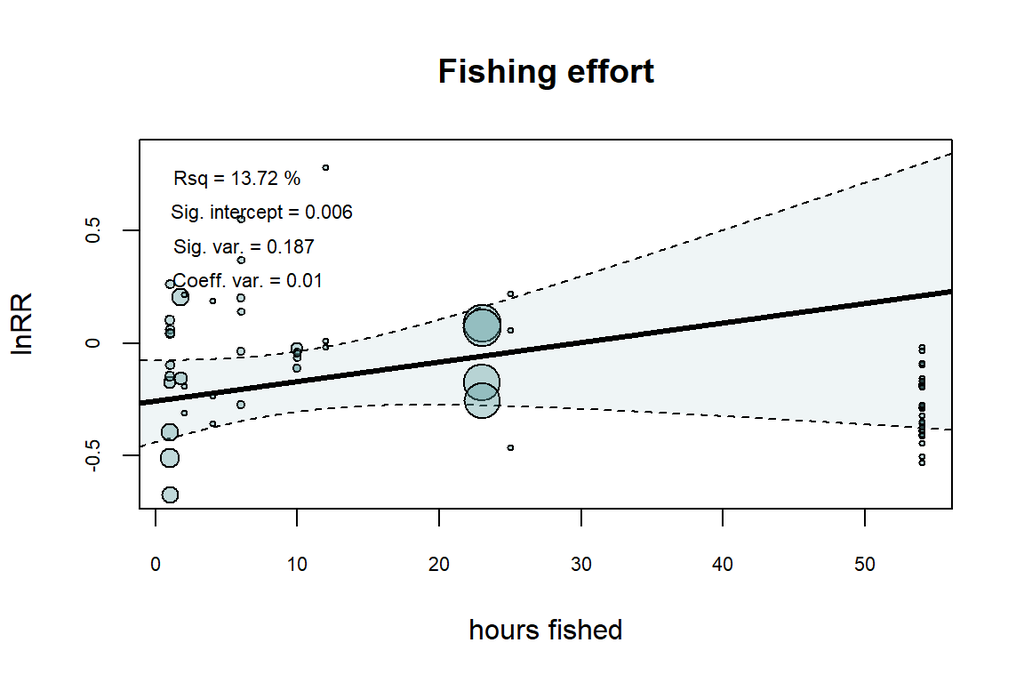

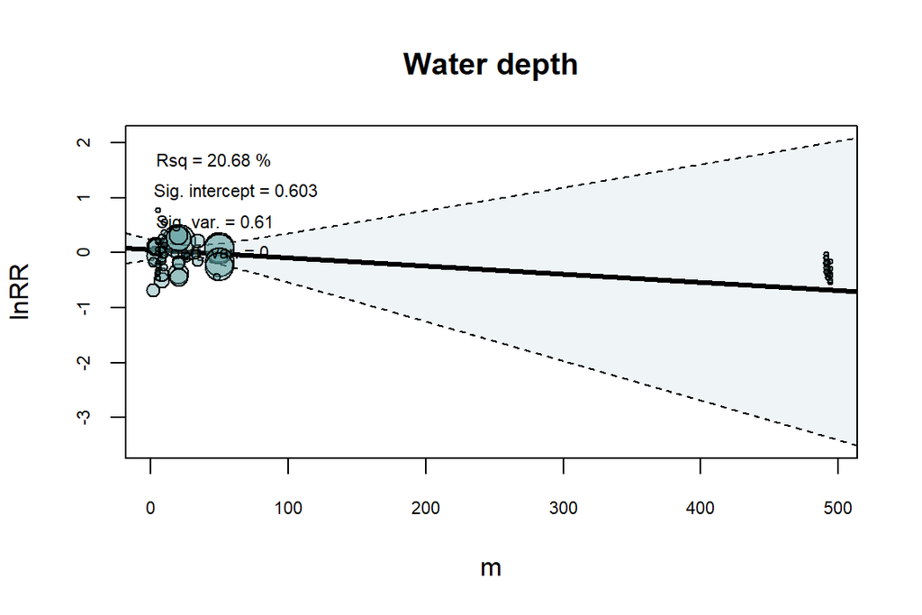

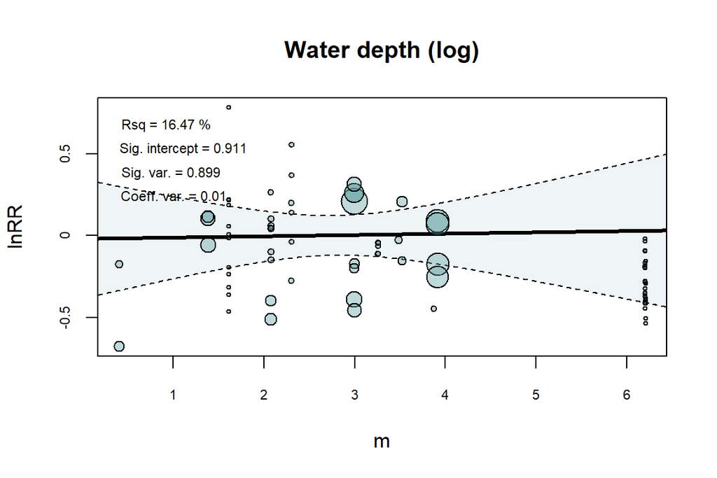

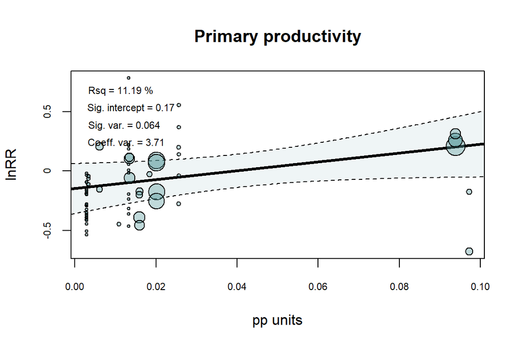

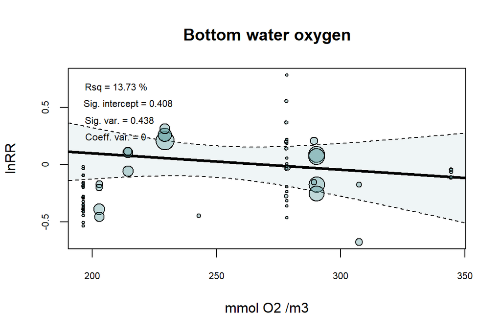

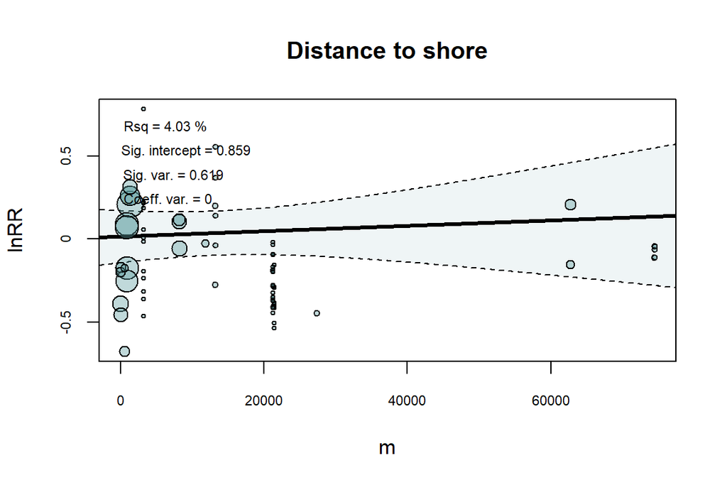

## 3.3 Full model selection

–> Cannot use heffortnum, too many datapoints missing and very biased.

OCshort[, c(20, 21, 24, 25, 31, 32)]

### 3.3.1 Stepwise

```
##
## Mixed-Effects Model (k = 73; tau^2 estimator: REML)
##
##   logLik  deviance       AIC       BIC      AICc
##  -1.8904    3.7807   13.7807   24.9513   14.7331
##
## tau^2 (estimated amount of residual heterogeneity):     0.0443 (SE = 0.0085)
## tau (square root of estimated tau^2 value):             0.2106
## R^2 (amount of heterogeneity accounted for):            29.90%
##
## Test of Moderators (coefficients 2:4):
## QM(df = 3) = 8.7715, p-val = 0.0325
##
## Model Results:
##
##               estimate      se     zval    pval    ci.lb    ci.ub
## intrcpt        -0.7657  0.4463  -1.7155  0.0863  -1.6405   0.1091  .
## cvel            1.6975  0.8726   1.9454  0.0517  -0.0127   3.4078  .
## hhabtypeSand   -0.2722  0.1147  -2.3726  0.0177  -0.4970  -0.0473  *
## O2bot           0.0025  0.0016   1.5610  0.1185  -0.0006   0.0057
##
## ---
## Signif. codes:  0 '***' 0.001 '**' 0.01 '*' 0.05 '.' 0.1 ' ' 1
```

### 3.3.2 Multimodel

OC short top 10 models

| model | aicc | weights |
| --- | --- | --- |
| lnRR ~ 1 + cvel | 4.345732 | 0.4983945 |
| lnRR ~ 1 + cvel + O2bot | 7.333117 | 0.1119105 |
| lnRR ~ 1 + watdepth + nppsurf + heffortnum | 7.356191 | 0.1106268 |
| lnRR ~ 1 + cvel + nppsurf + heffortnum | 7.812896 | 0.0880416 |
| lnRR ~ 1 + cvel + nppsurf | 10.084847 | 0.0282709 |
| lnRR ~ 1 + cvel + nppsurf + O2bot | 10.564837 | 0.0222388 |
| lnRR ~ 1 + hhabtype + watdepth + nppsurf + heffortnum | 10.735890 | 0.0204159 |
| lnRR ~ 1 + histfished + watdepth + nppsurf + heffortnum | 10.917300 | 0.0186456 |
| lnRR ~ 1 + cvel + watdepth + nppsurf + heffortnum | 10.999145 | 0.0178979 |
| lnRR ~ 1 + watdepth + nppsurf + timesincetrawl + heffortnum | 11.618164 | 0.0131336 |

```
##
## Mixed-Effects Model (k = 73; tau^2 estimator: REML)
##
##   logLik  deviance       AIC       BIC      AICc
##   1.0062   -2.0125    3.9875   10.7756    4.3457
##
## tau^2 (estimated amount of residual heterogeneity):     0.0465 (SE = 0.0088)
## tau (square root of estimated tau^2 value):             0.2155
## R^2 (amount of heterogeneity accounted for):            26.55%
##
## Test of Moderators (coefficient 2):
## QM(df = 1) = 4.8896, p-val = 0.0270
##
## Model Results:
##
##          estimate      se     zval    pval    ci.lb    ci.ub
## intrcpt   -0.3504  0.1673  -2.0947  0.0362  -0.6782  -0.0225  *
## cvel       2.1363  0.9661   2.2112  0.0270   0.2428   4.0298  *
##
## ---
## Signif. codes:  0 '***' 0.001 '**' 0.01 '*' 0.05 '.' 0.1 ' ' 1
```

# 4 RECOVERY OC

## 4.1 Individual variables

| Mods | Rsquared | Pvalue |
| --- | --- | --- |
| Slice depth | 8.552230 | 0.7025534 |
| Historically fished | 3.753257 | 0.9614937 |
| Season | 2.382474 | 0.9614743 |
| Sediment | 6.371300 | 0.8232132 |

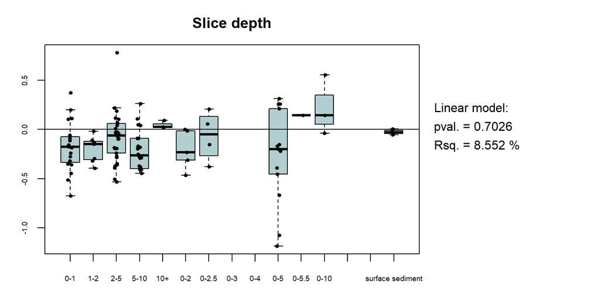

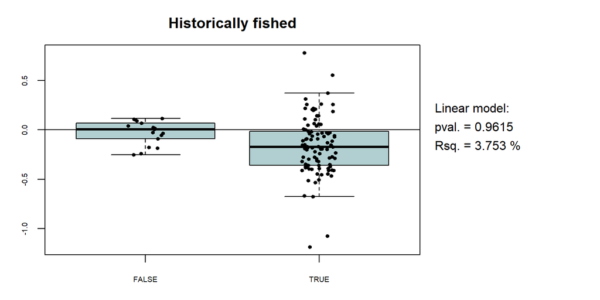

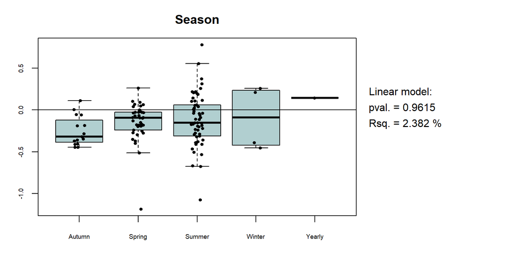

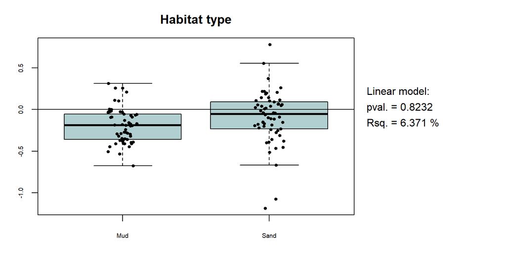

## 4.2 Continuous variables

| Mods | Rsquared | Pvalue |
| --- | --- | --- |
| Current velocity | 26.678411 | 0.0039208 |
| Hours fished | 11.668952 | 0.0487278 |
| Depth | 21.749193 | 0.8283212 |
| NPP surf. | 8.142168 | 0.0305428 |
| O2 bottom | 14.674928 | 0.9074155 |
| Dist. shore | 2.201918 | 0.5308820 |

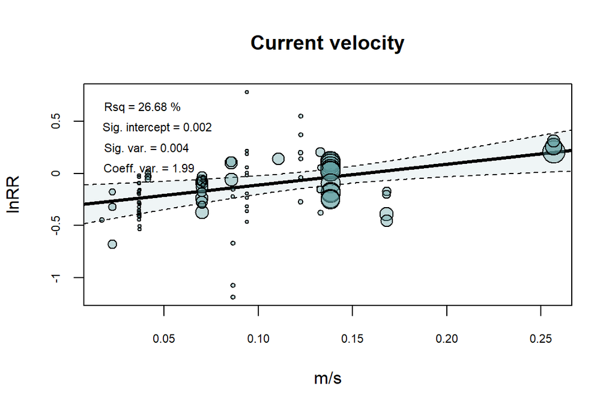

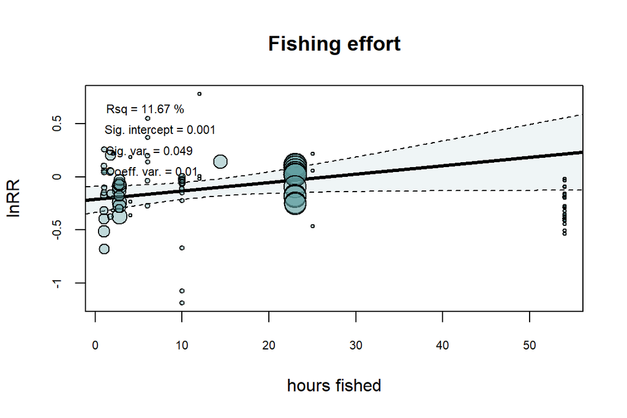

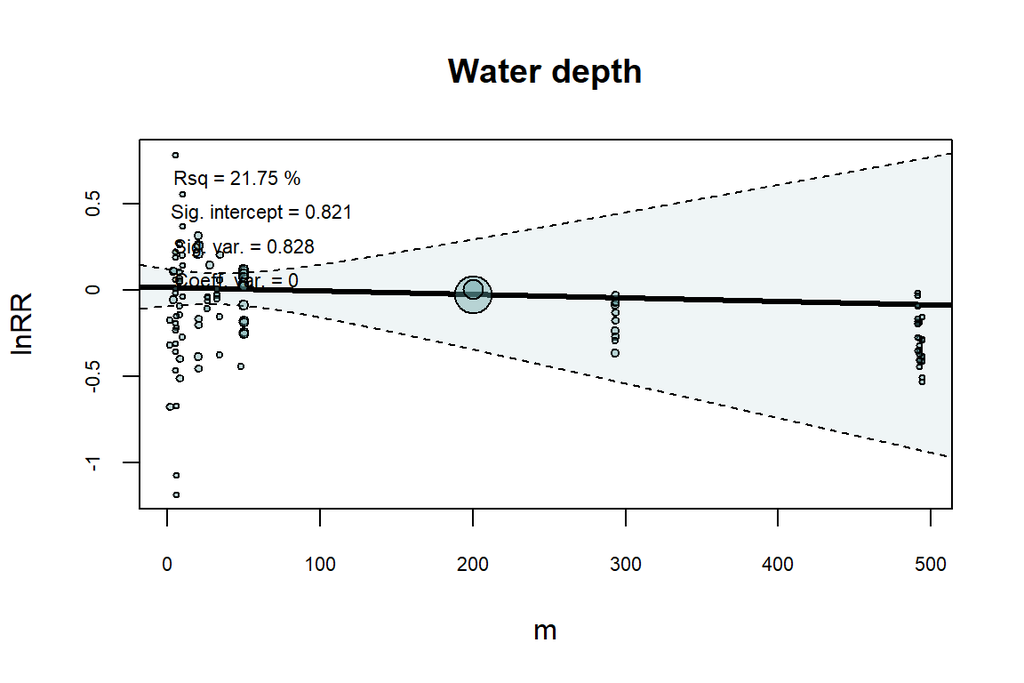

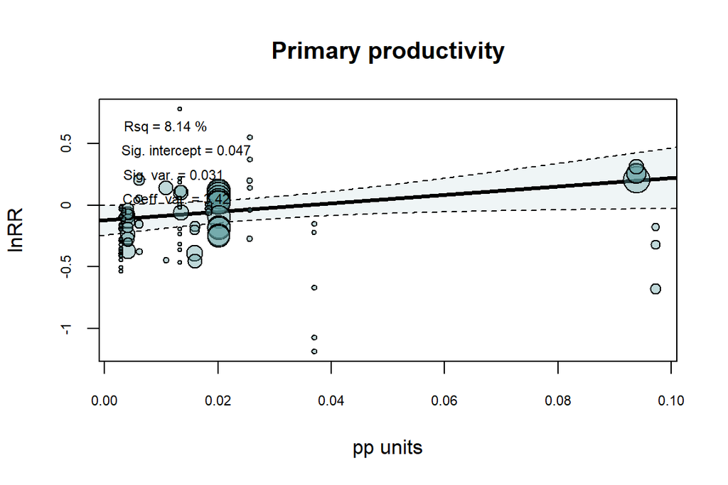

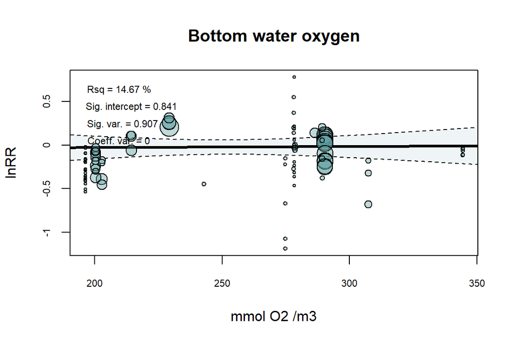

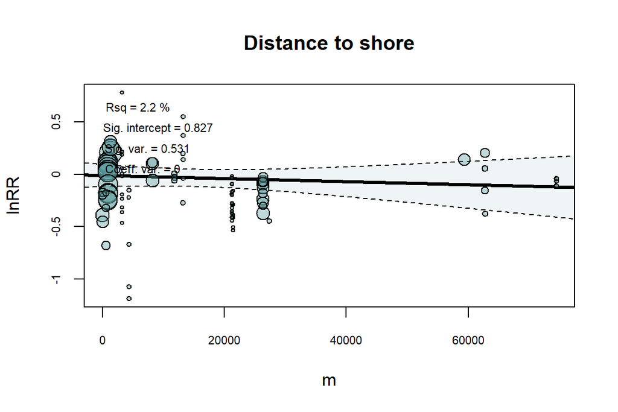

## 4.3 Full model selection

### 4.3.1 Stepwise

OCrec[, c(8, 20, 21, 24, 25, 31, 32, 35, 36, 87)]

```
##
## Mixed-Effects Model (k = 103; tau^2 estimator: REML)
##
##   logLik  deviance       AIC       BIC      AICc
##   3.9215   -7.8430   18.1570   50.7981   22.8842
##
## tau^2 (estimated amount of residual heterogeneity):     0.0338 (SE = 0.0059)
## tau (square root of estimated tau^2 value):             0.1838
## R^2 (amount of heterogeneity accounted for):            36.16%
##
## Test of Moderators (coefficients 2:12):
## QM(df = 11) = 27.6103, p-val = 0.0037
##
## Model Results:
##
##                              estimate      se     zval    pval    ci.lb
## intrcpt                       -0.5664  0.1165  -4.8614  <.0001  -0.7948
## cvel                           3.5597  1.0084   3.5301  0.0004   1.5833
## sslicedepth1-2                 0.1579  0.1756   0.8993  0.3685  -0.1863
## sslicedepth2-5                 0.1358  0.1077   1.2610  0.2073  -0.0752
## sslicedepth5-10                0.0021  0.1374   0.0155  0.9877  -0.2672
## sslicedepth10+                 0.1185  0.1373   0.8630  0.3881  -0.1506
## sslicedepth0-2                -0.0232  0.1162  -0.2000  0.8414  -0.2509
## sslicedepth0-2.5               0.1560  0.1565   0.9973  0.3186  -0.1506
## sslicedepth0-5                -0.1687  0.1671  -1.0094  0.3128  -0.4963
## sslicedepth0-5.5               0.3159  0.2063   1.5316  0.1256  -0.0884
## sslicedepth0-10                0.3316  0.2845   1.1657  0.2437  -0.2259
## sslicedepthsurface sediment    0.3924  0.1565   2.5065  0.0122   0.0856
##                                ci.ub
## intrcpt                      -0.3380  ***
## cvel                          5.5361  ***
## sslicedepth1-2                0.5021
## sslicedepth2-5                0.3468
## sslicedepth5-10               0.2714
## sslicedepth10+                0.3876
## sslicedepth0-2                0.2044
## sslicedepth0-2.5              0.4627
## sslicedepth0-5                0.1589
## sslicedepth0-5.5              0.7202
## sslicedepth0-10               0.8892
## sslicedepthsurface sediment   0.6992    *
##
## ---
## Signif. codes:  0 '***' 0.001 '**' 0.01 '*' 0.05 '.' 0.1 ' ' 1
```

### 4.3.2 Multimodel

| model | aicc | weights |
| --- | --- | --- |
| lnRR ~ 1 + cvel | -3.3331003 | 0.1571226 |
| lnRR ~ 1 + cvel + O2bot | -2.5738338 | 0.1074895 |
| lnRR ~ 1 + cvel + watdepth | -2.2106048 | 0.0896379 |
| lnRR ~ 1 + nppsurf + O2bot + heffortnum | -2.0285462 | 0.0818386 |
| lnRR ~ 1 + hhabtype + nppsurf + heffortnum | -1.3784279 | 0.0591271 |
| lnRR ~ 1 + hhabtype + cvel + watdepth | -0.8922723 | 0.0463681 |
| lnRR ~ 1 + cvel + log(timesincetrawl + 1) | -0.8350625 | 0.0450606 |
| lnRR ~ 1 + histfished + cvel | -0.8279807 | 0.0449013 |
| lnRR ~ 1 + nppsurf + O2bot + heffortnum + log(timesincetrawl + 1) | -0.7815032 | 0.0438699 |
| lnRR ~ 1 + cvel + nppsurf + O2bot + heffortnum | -0.5605520 | 0.0392814 |

```
##
## Mixed-Effects Model (k = 103; tau^2 estimator: REML)
##
##   logLik  deviance       AIC       BIC      AICc
##   4.7903   -9.5805   -3.5805    4.2648   -3.3331
##
## tau^2 (estimated amount of residual heterogeneity):     0.0385 (SE = 0.0064)
## tau (square root of estimated tau^2 value):             0.1961
## R^2 (amount of heterogeneity accounted for):            27.30%
##
## Test of Moderators (coefficient 2):
## QM(df = 1) = 8.5415, p-val = 0.0035
##
## Model Results:
##
##          estimate      se     zval    pval    ci.lb    ci.ub
## intrcpt   -0.3106  0.0984  -3.1566  0.0016  -0.5034  -0.1177  **
## cvel       1.9950  0.6826   2.9226  0.0035   0.6571   3.3329  **
##
## ---
## Signif. codes:  0 '***' 0.001 '**' 0.01 '*' 0.05 '.' 0.1 ' ' 1
```

# 5 ALL DATA OC

## 5.1 Individual variables

| Mods | Rsquared | Pvalue |
| --- | --- | --- |
| Slice depth | 7.033676 | 0.1927502 |
| Historically fished | 2.423430 | 0.6891433 |
| Season | 4.192325 | 0.4229664 |
| Sediment | 3.963371 | 0.9153210 |

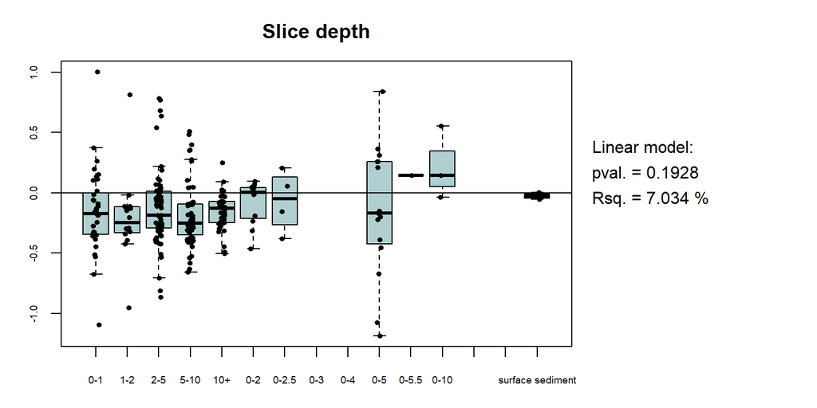

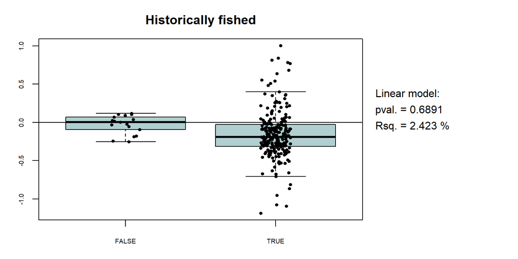

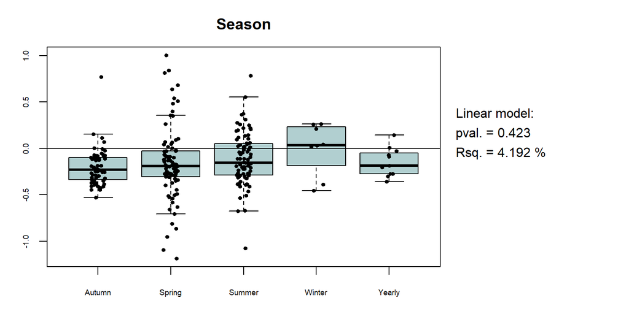

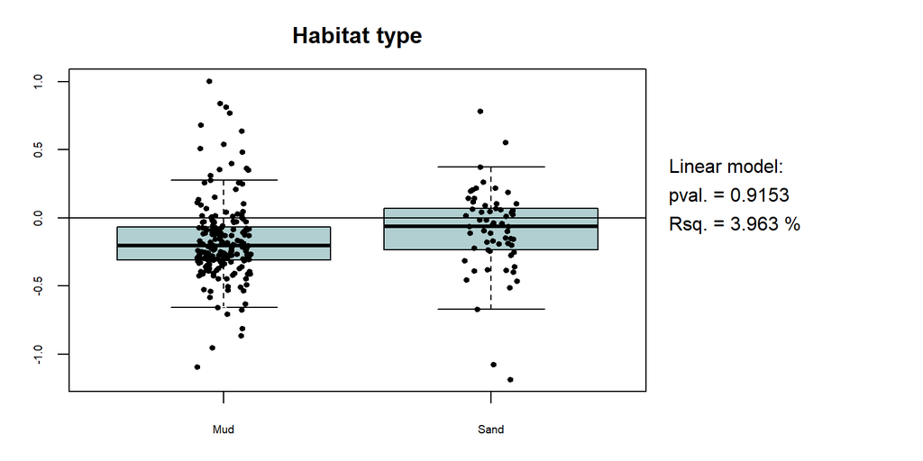

## 5.2 Continuous variables

| Mods | Rsquared | Pvalue |
| --- | --- | --- |
| Current velocity | 13.66514 | 0.0006080 |
| Hours fished | 7.71458 | 0.0237375 |
| Depth | 16.94361 | 0.0476176 |
| NPP surf. | 5.09948 | 0.0029593 |
| O2 bottom | 16.43346 | 0.1203549 |
| Dist. shore | 0.00000 | 0.4029564 |

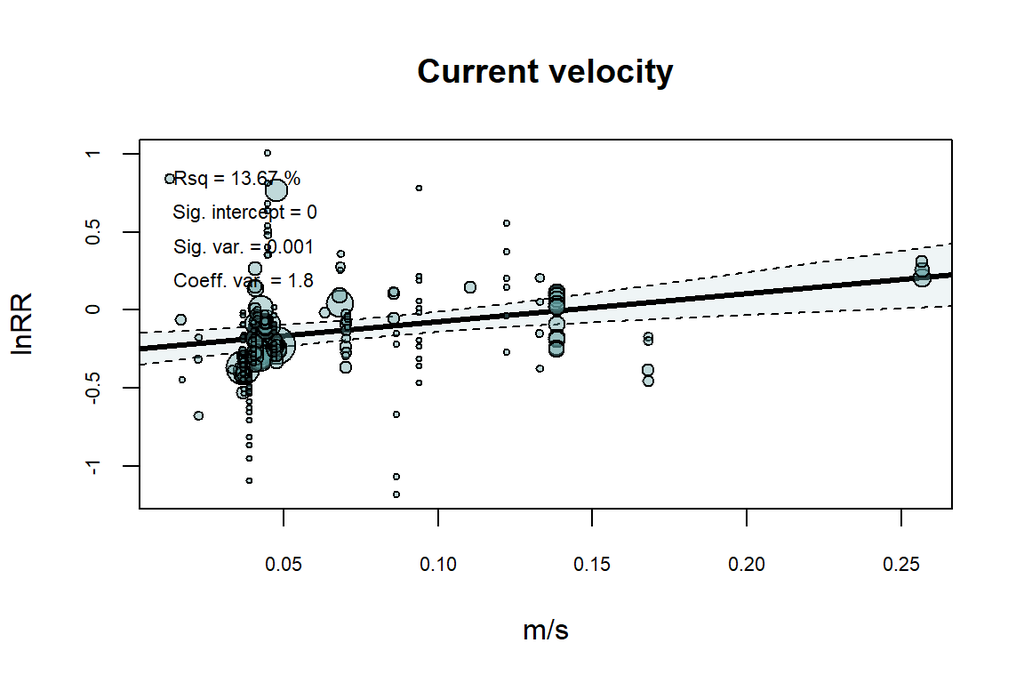

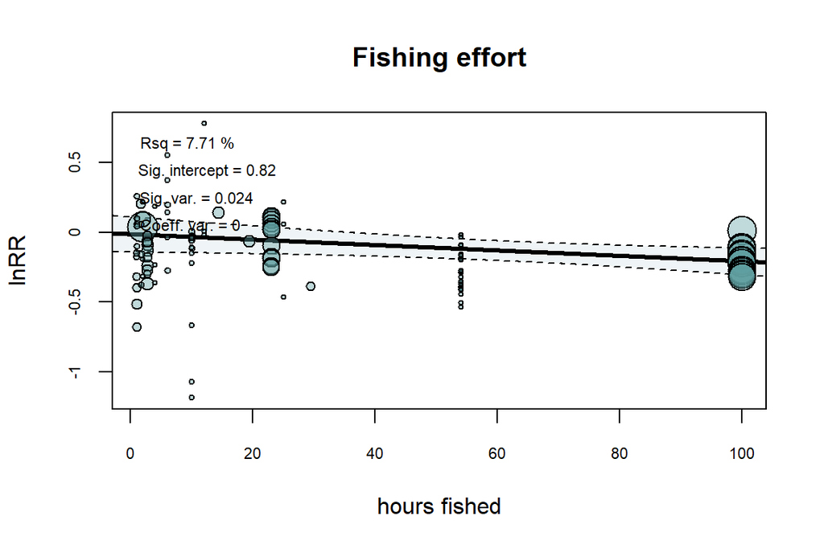

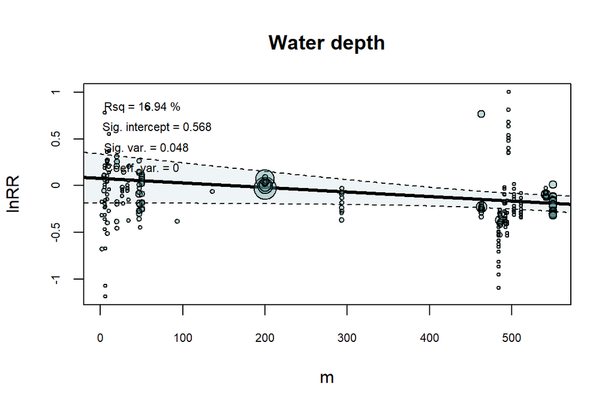

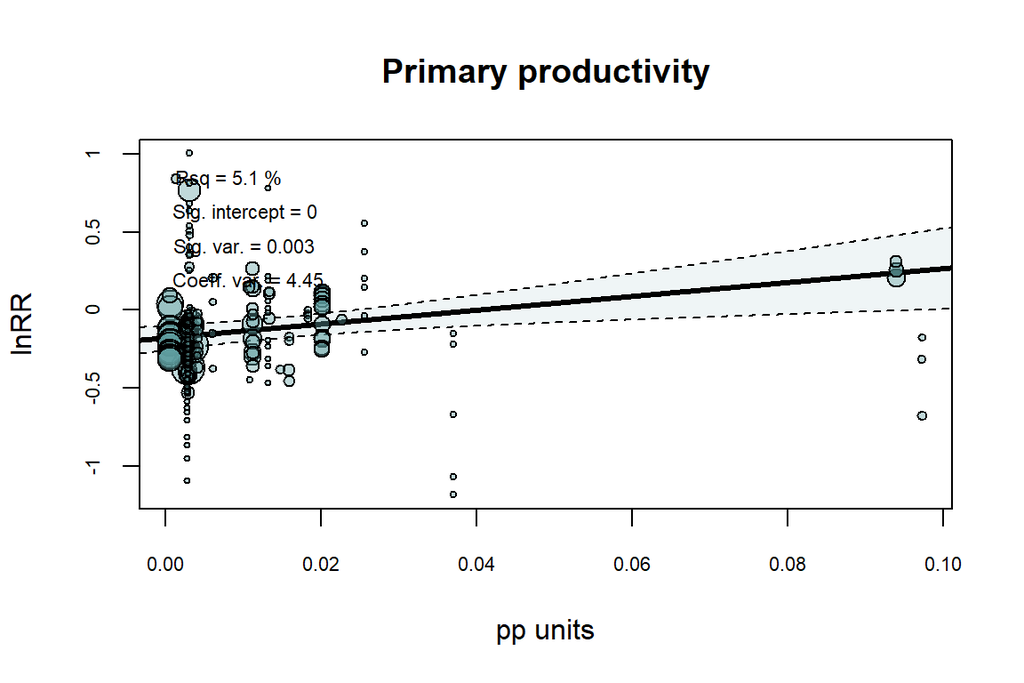

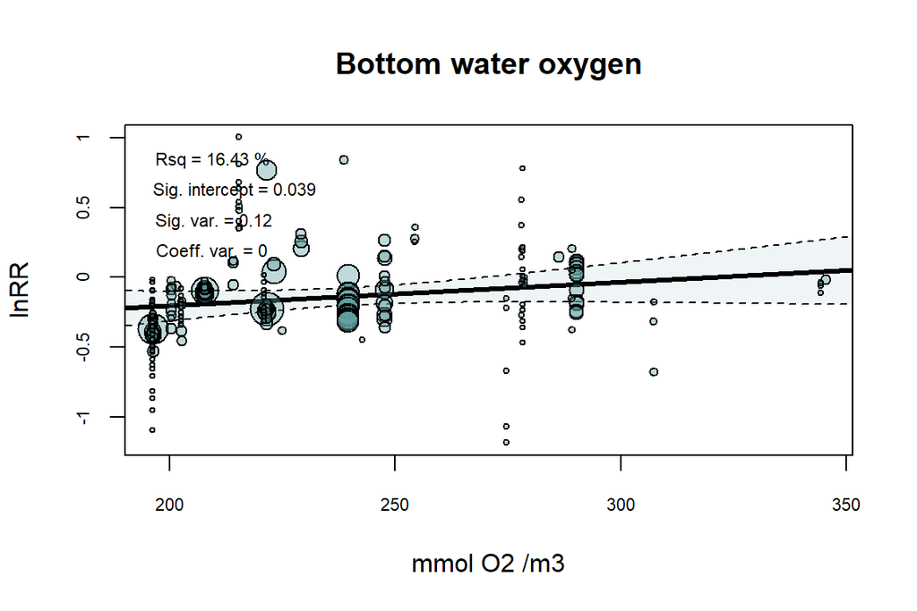

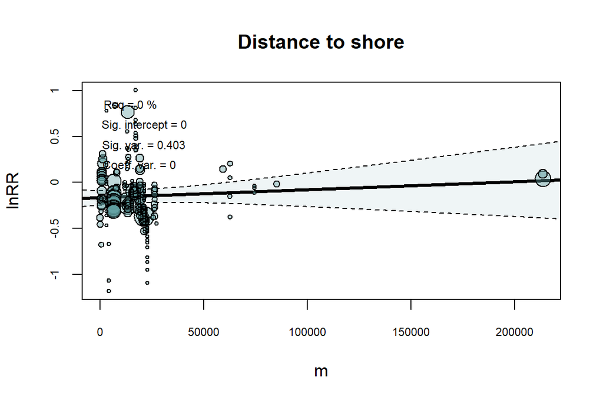

```
##                cvel   watdepth    nppsurf
## cvel      1.0000000 -0.6169198  0.5740851
## watdepth -0.6169198  1.0000000 -0.5460304
## nppsurf   0.5740851 -0.5460304  1.0000000
```

## 5.3 Full model selection

### 5.3.1 Stepwise

- Not using heffortnum here because there is too much missing data.
- Not using timessincetrawl.
- Not using 167, 111, 185.
- Note, “yearly” as season is a bit strange.
- OCall[, c(8, 20, 21, 24, 25, 31, 32, 35, 36, 87)]

```
##
## Mixed-Effects Model (k = 225; tau^2 estimator: REML)
##
##   logLik  deviance       AIC       BIC      AICc
## -20.3151   40.6301   52.6301   72.9919   53.0245
##
## tau^2 (estimated amount of residual heterogeneity):     0.0495 (SE = 0.0053)
## tau (square root of estimated tau^2 value):             0.2224
## R^2 (amount of heterogeneity accounted for):            23.22%
##
## Test of Moderators (coefficients 2:5):
## QM(df = 4) = 13.3799, p-val = 0.0096
##
## Model Results:
##
##               estimate      se     zval    pval    ci.lb    ci.ub
## intrcpt        -0.4012  0.4705  -0.8528  0.3938  -1.3234   0.5209
## cvel            1.6477  0.6807   2.4206  0.0155   0.3135   2.9819  *
## hhabtypeSand   -0.1993  0.1001  -1.9898  0.0466  -0.3955  -0.0030  *
## watdepth       -0.0002  0.0002  -1.1476  0.2511  -0.0006   0.0001
## O2bot           0.0011  0.0018   0.5971  0.5504  -0.0025   0.0047
##
## ---
## Signif. codes:  0 '***' 0.001 '**' 0.01 '*' 0.05 '.' 0.1 ' ' 1
```

### 5.3.2 Multimodel

| model | aicc | weights |
| --- | --- | --- |
| lnRR ~ 1 + hseason + hhabtype + cvel + watdepth + nppsurf + O2bot | 49.00808 | 0.1811395 |
| lnRR ~ 1 + hhabtype + cvel + watdepth + nppsurf + O2bot | 49.11180 | 0.1719847 |
| lnRR ~ 1 + cvel + O2bot | 50.25217 | 0.0972438 |
| lnRR ~ 1 + hhabtype + cvel + O2bot | 51.12693 | 0.0627930 |
| lnRR ~ 1 + hhabtype + cvel + nppsurf + O2bot | 51.16100 | 0.0617324 |
| lnRR ~ 1 + cvel + O2bot + shoredist | 51.73943 | 0.0462283 |
| lnRR ~ 1 + histfished + hhabtype + cvel + watdepth + nppsurf + O2bot | 51.86848 | 0.0433395 |
| lnRR ~ 1 + histfished + cvel + O2bot | 52.23074 | 0.0361595 |
| lnRR ~ 1 + cvel + nppsurf + O2bot | 52.23405 | 0.0360997 |
| lnRR ~ 1 + histfished + hseason + hhabtype + cvel + watdepth + nppsurf + O2bot | 52.28968 | 0.0351093 |

```
##
## Mixed-Effects Model (k = 225; tau^2 estimator: REML)
##
##   logLik  deviance       AIC       BIC      AICc
## -24.1011   48.2023   68.2023  101.9550   69.2754
##
## tau^2 (estimated amount of residual heterogeneity):     0.0490 (SE = 0.0053)
## tau (square root of estimated tau^2 value):             0.2213
## R^2 (amount of heterogeneity accounted for):            23.96%
##
## Test of Moderators (coefficients 2:9):
## QM(df = 8) = 19.8860, p-val = 0.0108
##
## Model Results:
##
##                estimate      se     zval    pval    ci.lb    ci.ub
## intrcpt         -1.0984  0.6502  -1.6895  0.0911  -2.3727   0.1758  .
## hseasonSpring    0.0159  0.1015   0.1563  0.8758  -0.1830   0.2147
## hseasonSummer   -0.1518  0.1177  -1.2904  0.1969  -0.3824   0.0788
## hseasonWinter   -0.0311  0.1849  -0.1683  0.8664  -0.3935   0.3313
## hseasonYearly   -0.3417  0.1549  -2.2057  0.0274  -0.6454  -0.0381  *
## hhabtypeSand    -0.2504  0.1025  -2.4428  0.0146  -0.4513  -0.0495  *
## cvel             1.0985  0.8992   1.2216  0.2219  -0.6640   2.8610
## watdepth        -0.0004  0.0002  -1.5700  0.1164  -0.0008   0.0001
## O2bot            0.0050  0.0028   1.7954  0.0726  -0.0005   0.0104  .
##
## ---
## Signif. codes:  0 '***' 0.001 '**' 0.01 '*' 0.05 '.' 0.1 ' ' 1
```

# 6 SHORT TERM CHL A

## 6.1 Individual variables

- One observation with VarLnRR > 8 is removed or it does not work with ~sslicedepth.

| Mods | Rsquared | Pvalue |
| --- | --- | --- |
| Slice depth | 5.349325 | 0.1644452 |
| Historically fished | 2.083371 | 0.1210784 |
| Season | 13.044041 | 0.0296907 |
| Sediment | 1.833025 | 0.1792993 |

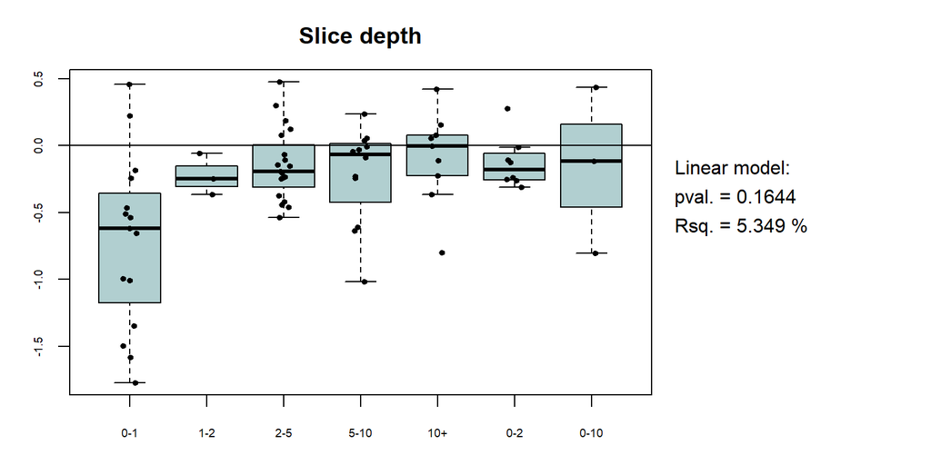

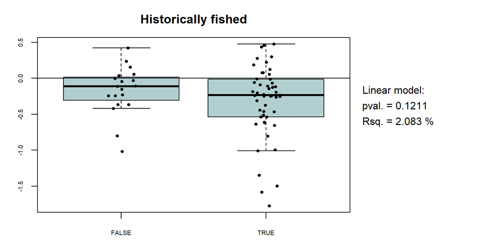

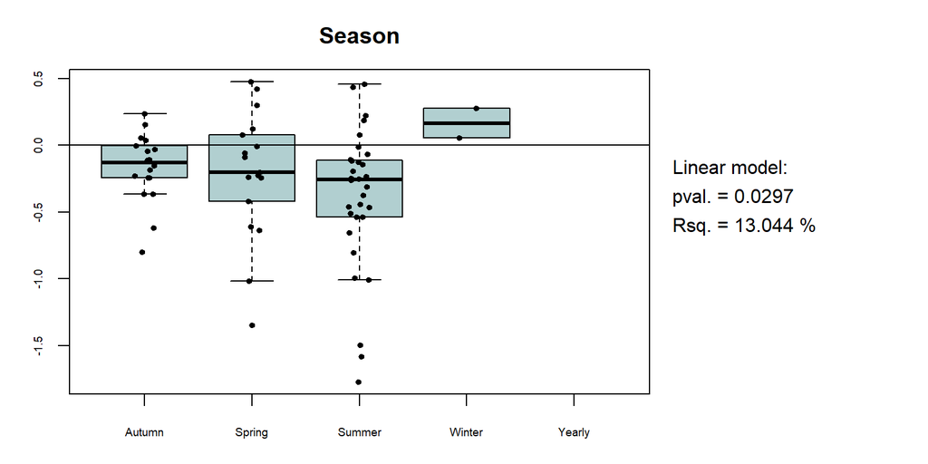

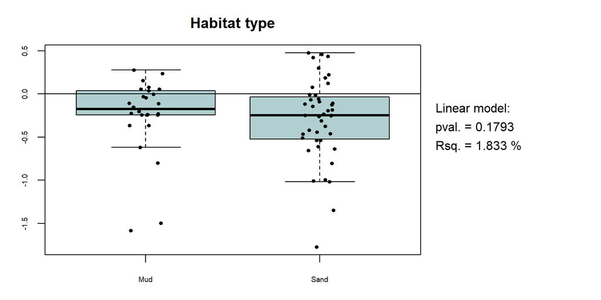

## 6.2 Continuous variables

| Mods | Rsquared | Pvalue |
| --- | --- | --- |
| Current velocity | 0.000000 | 0.1909770 |
| Hours fished | 0.000000 | 0.2986341 |
| Depth | 7.909253 | 0.1673183 |
| NPP surf. | 28.845661 | 0.0000050 |
| O2 bottom | 3.739989 | 0.1168612 |
| Dist. shore | 0.000000 | 0.4304080 |

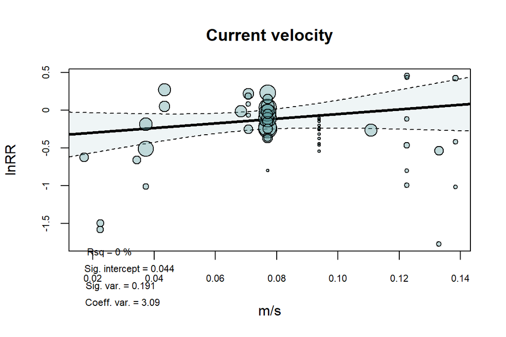

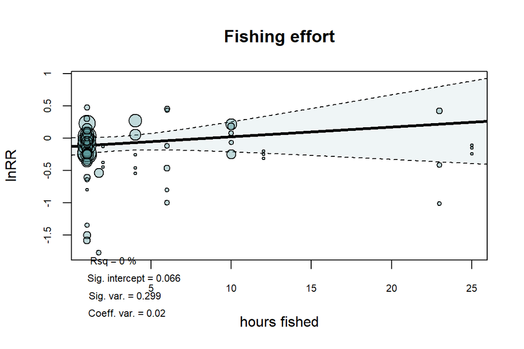

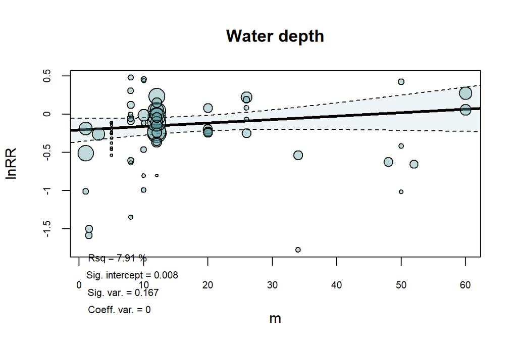

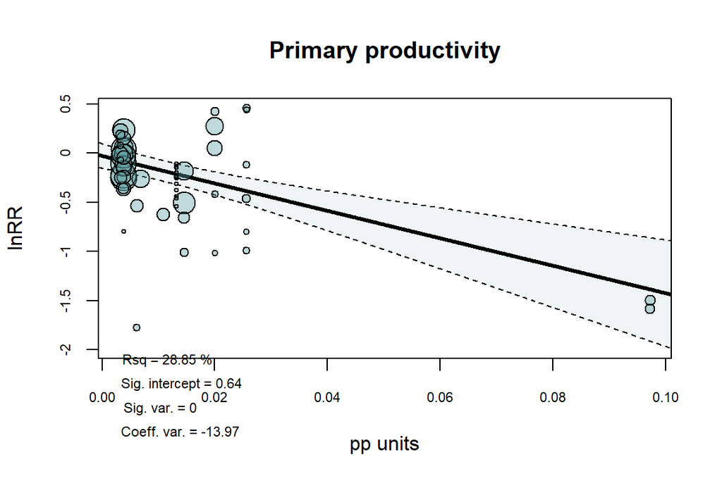

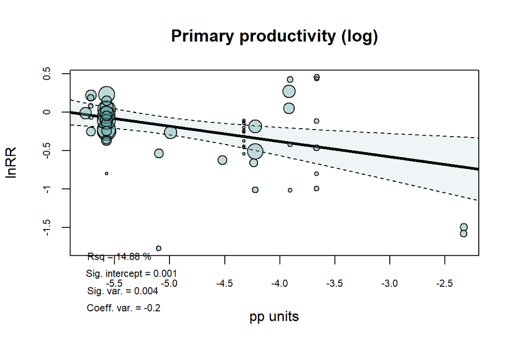

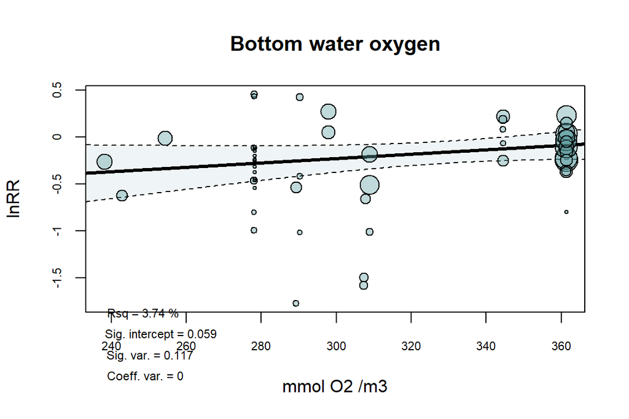

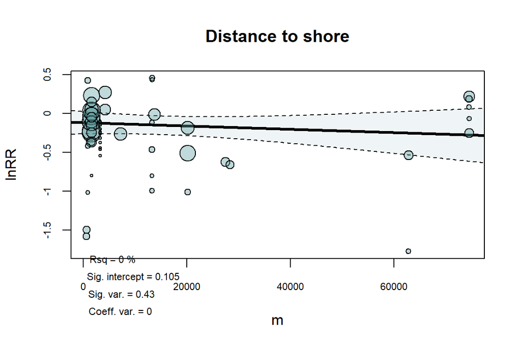

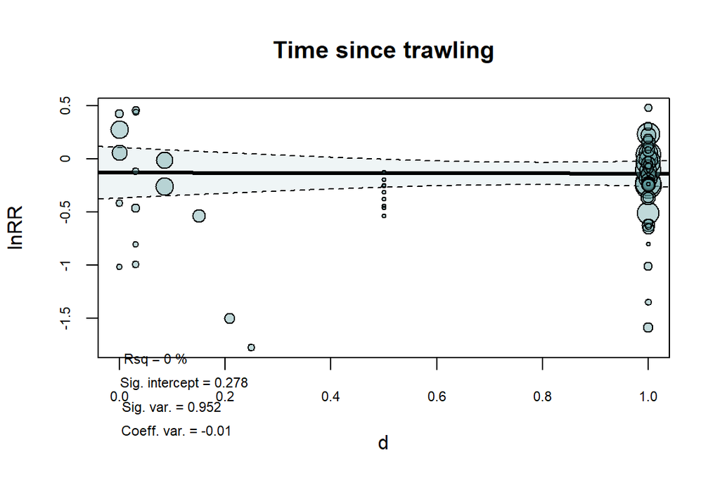

## 6.3 Full model selection

### 6.3.1 Stepwise

–> Redo with heffortnum

CHshort[, c(8, 20, 21, 24, 25, 31, 32, 35, 36, 87)]

```
##
## Mixed-Effects Model (k = 50; tau^2 estimator: REML)
##
##   logLik  deviance       AIC       BIC      AICc
## -21.4829   42.9658   52.9658   62.1090   54.4658
##
## tau^2 (estimated amount of residual heterogeneity):     0.0379 (SE = 0.0122)
## tau (square root of estimated tau^2 value):             0.1948
## R^2 (amount of heterogeneity accounted for):            39.95%
##
## Test of Moderators (coefficients 2:4):
## QM(df = 3) = 30.6331, p-val < .0001
##
## Model Results:
##
##             estimate      se     zval    pval     ci.lb     ci.ub
## intrcpt       0.5081  0.2233   2.2758  0.0229    0.0705    0.9457    *
## cvel         -7.0092  2.6809  -2.6145  0.0089  -12.2638   -1.7547   **
## nppsurf     -17.3164  3.2050  -5.4030  <.0001  -23.5980  -11.0348  ***
## heffortnum    0.0284  0.0140   2.0335  0.0420    0.0010    0.0557    *
##
## ---
## Signif. codes:  0 '***' 0.001 '**' 0.01 '*' 0.05 '.' 0.1 ' ' 1
```

### 6.3.2 Multimodel

| model | aicc | weights |
| --- | --- | --- |
| lnRR ~ 1 + watdepth + nppsurf + heffortnum | 35.55554 | 0.1637868 |
| lnRR ~ 1 + cvel + nppsurf + O2bot + heffortnum + timesincetrawl | 35.68937 | 0.1531857 |
| lnRR ~ 1 + cvel + watdepth + nppsurf + heffortnum | 36.99160 | 0.0798811 |
| lnRR ~ 1 + histfished + watdepth + nppsurf + heffortnum | 37.63657 | 0.0578616 |
| lnRR ~ 1 + watdepth + nppsurf + O2bot + heffortnum | 38.10583 | 0.0457607 |
| lnRR ~ 1 + watdepth + nppsurf + heffortnum + timesincetrawl | 38.16197 | 0.0444939 |
| lnRR ~ 1 + hseason + nppsurf | 38.84579 | 0.0316091 |
| lnRR ~ 1 + nppsurf + O2bot + heffortnum + timesincetrawl | 38.86614 | 0.0312890 |
| lnRR ~ 1 + hhabtype + watdepth + nppsurf + heffortnum | 39.43587 | 0.0235330 |
| lnRR ~ 1 + hseason + watdepth + nppsurf | 39.62221 | 0.0214394 |

```
##
## Mixed-Effects Model (k = 50; tau^2 estimator: REML)
##
##   logLik  deviance       AIC       BIC      AICc
## -12.0278   24.0555   34.0555   43.1988   35.5555
##
## tau^2 (estimated amount of residual heterogeneity):     0.0358 (SE = 0.0116)
## tau (square root of estimated tau^2 value):             0.1893
## R^2 (amount of heterogeneity accounted for):            43.26%
##
## Test of Moderators (coefficients 2:4):
## QM(df = 3) = 30.3870, p-val < .0001
##
## Model Results:
##
##             estimate      se     zval    pval     ci.lb    ci.ub
## intrcpt      -0.1317  0.0861  -1.5293  0.1262   -0.3005   0.0371
## watdepth      0.0079  0.0039   2.0024  0.0452    0.0002   0.0156    *
## nppsurf     -13.9471  2.8218  -4.9426  <.0001  -19.4778  -8.4164  ***
## heffortnum    0.0042  0.0150   0.2790  0.7802   -0.0252   0.0336
##
## ---
## Signif. codes:  0 '***' 0.001 '**' 0.01 '*' 0.05 '.' 0.1 ' ' 1
```

# 7 RECOVERY CHL A

## 7.1 Individual variables

| Mods | Rsquared | Pvalue |
| --- | --- | --- |
| Slice depth | 4.446666 | 0.0219594 |
| Historically fished | 5.084141 | 0.0395353 |
| Season | 4.162632 | 0.4186942 |
| Sediment | 4.070523 | 0.0266126 |

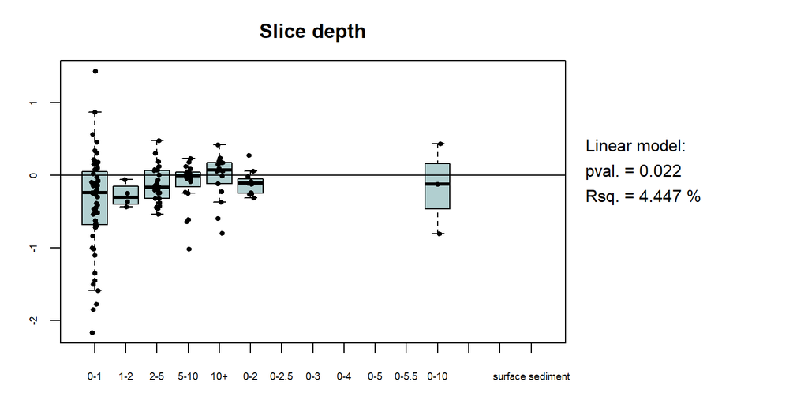

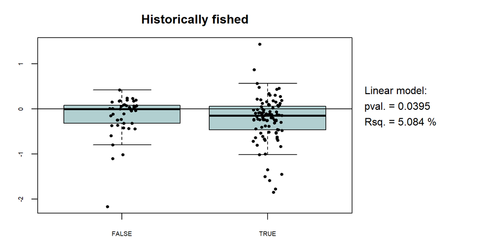

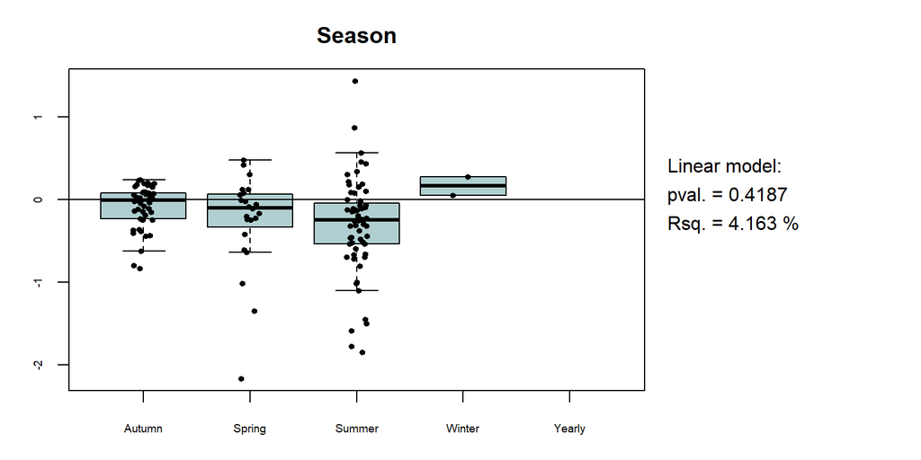

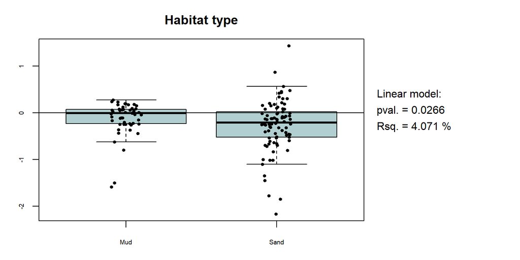

## 7.2 Continuous variables

| Mods | Rsquared | Pvalue |
| --- | --- | --- |
| Current velocity | 0.000000 | 0.0314185 |
| Hours fished | 0.000000 | 0.8701161 |
| Depth | 1.182804 | 0.6124197 |
| NPP surf. | 12.136847 | 0.0015085 |
| O2 bottom | 8.480961 | 0.0134721 |
| Dist. shore | 0.000000 | 0.0409077 |

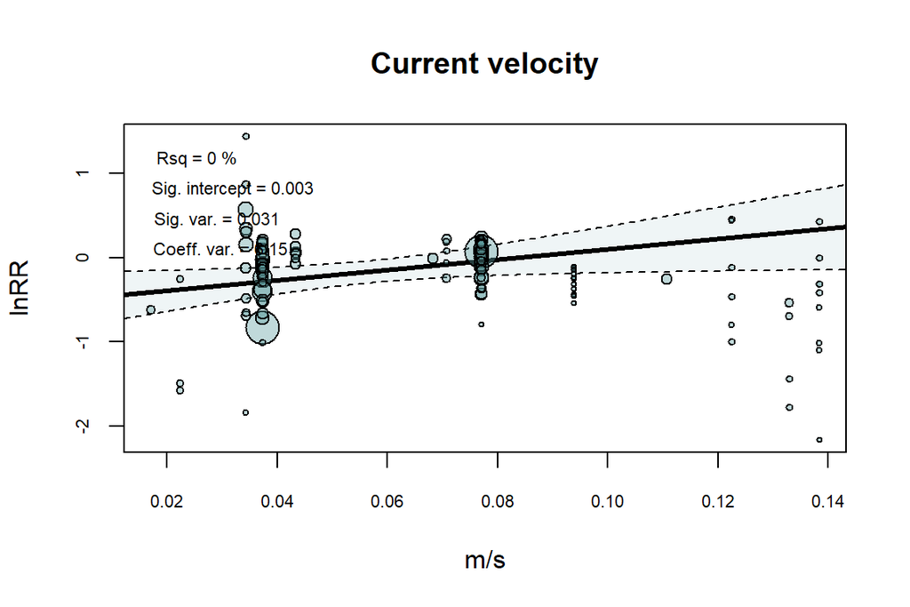

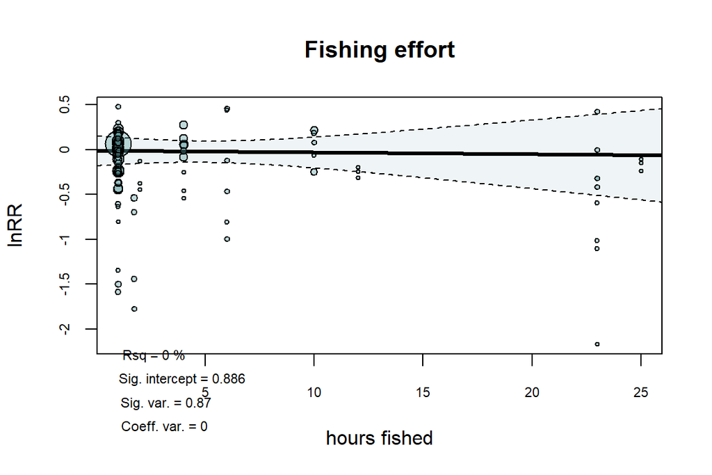

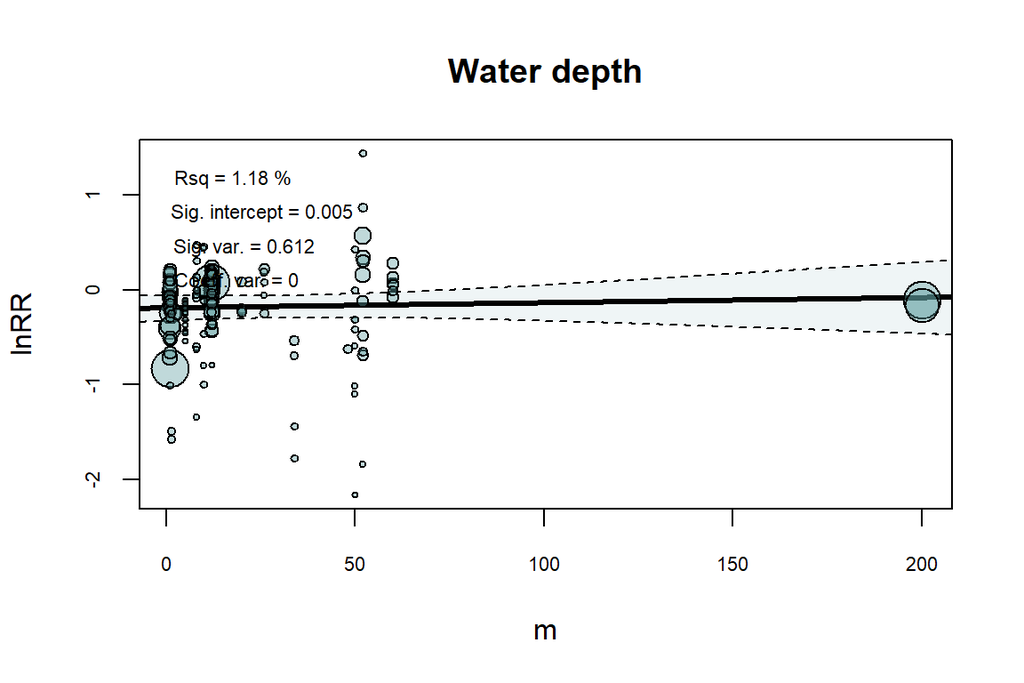

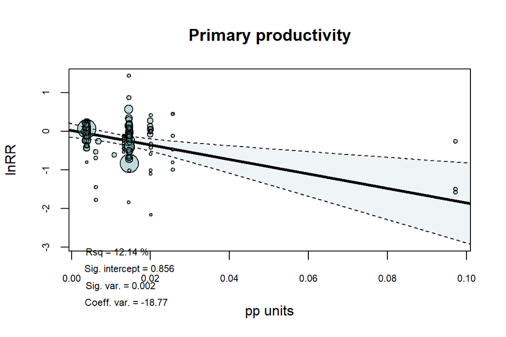

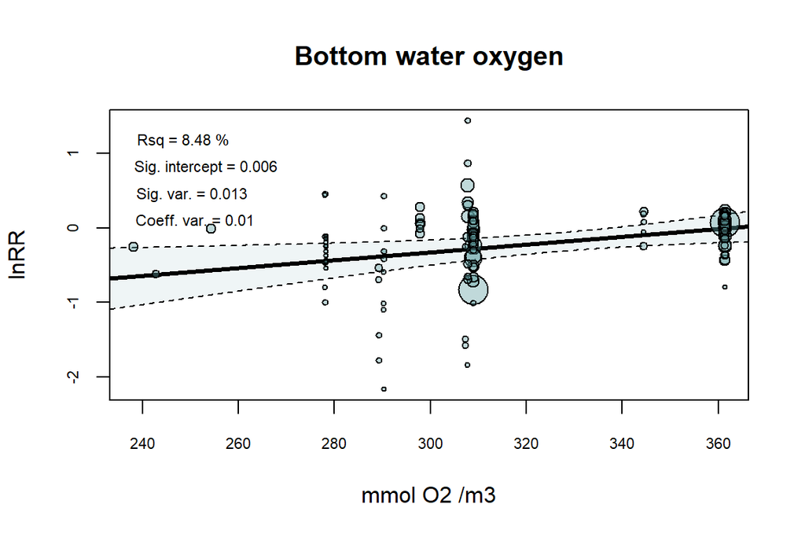

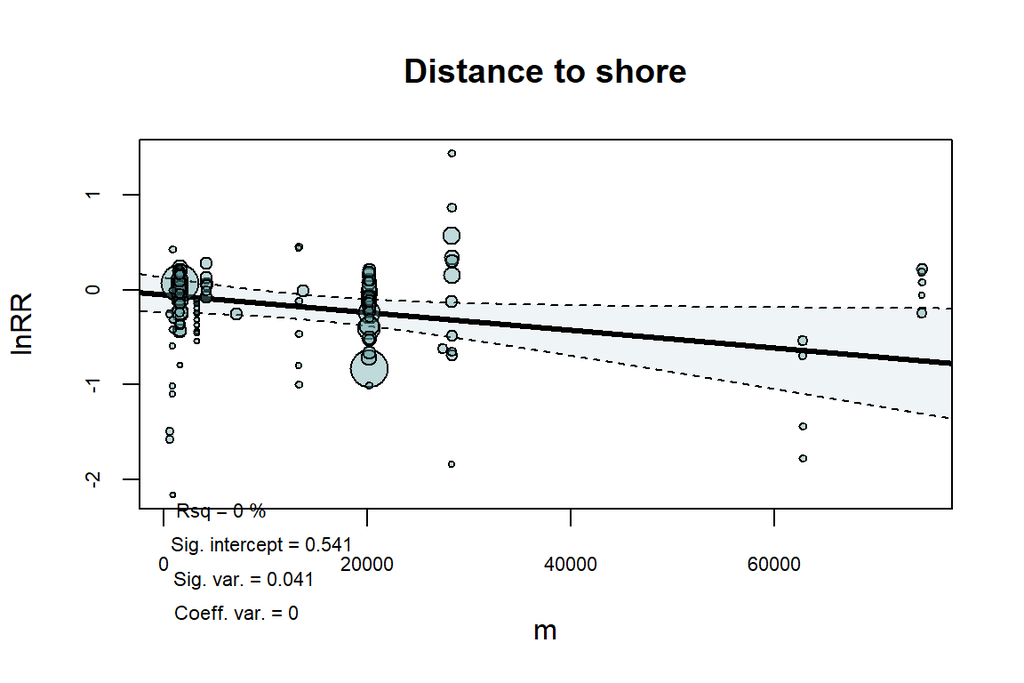

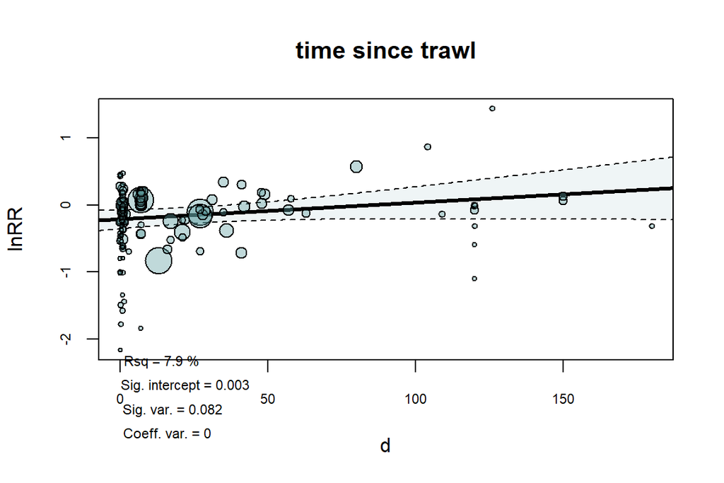

## 7.3 Full model selection

### 7.3.1 Stepwise

- Cannot use heffortnum

```
##
## Mixed-Effects Model (k = 121; tau^2 estimator: REML)
##
##   logLik  deviance       AIC       BIC      AICc
## -52.4413  104.8827  128.8827  161.2885  132.0992
##
## tau^2 (estimated amount of residual heterogeneity):     0.0599 (SE = 0.0115)
## tau (square root of estimated tau^2 value):             0.2447
## R^2 (amount of heterogeneity accounted for):            29.82%
##
## Test of Moderators (coefficients 2:11):
## QM(df = 10) = 39.7210, p-val < .0001
##
## Model Results:
##
##                  estimate      se     zval    pval     ci.lb    ci.ub
## intrcpt           -1.2366  0.7101  -1.7414  0.0816   -2.6285   0.1552    .
## sslicedepth1-2    -0.2488  0.2163  -1.1503  0.2500   -0.6727   0.1751
## sslicedepth2-5     0.1711  0.2042   0.8378  0.4021   -0.2292   0.5714
## sslicedepth5-10    0.1201  0.1280   0.9379  0.3483   -0.1309   0.3710
## sslicedepth10+     0.2215  0.1458   1.5193  0.1287   -0.0642   0.5072
## sslicedepth0-2     0.1052  0.1620   0.6495  0.5160   -0.2123   0.4228
## sslicedepth0-10    0.5570  0.4658   1.1959  0.2317   -0.3559   1.4700
## watdepth           0.0069  0.0023   2.9874  0.0028    0.0024   0.0115   **
## O2bot              0.0029  0.0021   1.3401  0.1802   -0.0013   0.0070
## nppsurf          -10.4749  2.9265  -3.5794  0.0003  -16.2107  -4.7391  ***
## timesincetrawl     0.0039  0.0014   2.8987  0.0037    0.0013   0.0066   **
##
## ---
## Signif. codes:  0 '***' 0.001 '**' 0.01 '*' 0.05 '.' 0.1 ' ' 1
```

### 7.3.2 Multimodel

| model | aicc | weights |
| --- | --- | --- |
| lnRR ~ 1 + timesincetrawl | 120.9743 | 0.2013362 |
| lnRR ~ 1 + hhabtype + watdepth + nppsurf + O2bot + shoredist | 123.7747 | 0.0496383 |
| lnRR ~ 1 + watdepth + timesincetrawl | 124.4006 | 0.0362991 |
| lnRR ~ 1 + watdepth + nppsurf + shoredist | 124.8298 | 0.0292884 |
| lnRR ~ 1 + histfished + hseason + cvel + nppsurf | 125.1720 | 0.0246825 |
| lnRR ~ 1 + histfished + watdepth + nppsurf + O2bot + shoredist | 125.3024 | 0.0231252 |
| lnRR ~ 1 + watdepth + nppsurf + shoredist + timesincetrawl | 125.3947 | 0.0220817 |
| lnRR ~ 1 + watdepth + nppsurf + O2bot + shoredist | 125.4628 | 0.0213428 |
| lnRR ~ 1 + histfished + hhabtype + watdepth + nppsurf + O2bot + shoredist | 125.5080 | 0.0208652 |
| lnRR ~ 1 + hseason + cvel + watdepth + nppsurf + O2bot + shoredist | 125.5948 | 0.0199793 |

```
##
## Mixed-Effects Model (k = 123; tau^2 estimator: REML)
##
##   logLik  deviance       AIC       BIC      AICc
## -57.3846  114.7691  120.7691  129.1565  120.9743
##
## tau^2 (estimated amount of residual heterogeneity):     0.0757 (SE = 0.0132)
## tau (square root of estimated tau^2 value):             0.2752
## R^2 (amount of heterogeneity accounted for):            8.15%
##
## Test of Moderators (coefficient 2):
## QM(df = 1) = 2.8689, p-val = 0.0903
##
## Model Results:
##
##                 estimate      se     zval    pval    ci.lb    ci.ub
## intrcpt          -0.2186  0.0760  -2.8780  0.0040  -0.3675  -0.0697  **
## timesincetrawl    0.0025  0.0015   1.6938  0.0903  -0.0004   0.0054   .
##
## ---
## Signif. codes:  0 '***' 0.001 '**' 0.01 '*' 0.05 '.' 0.1 ' ' 1
```

# 8 ALL DATA CHL A

## 8.1 Individual variables

| Mods | Rsquared | Pvalue |
| --- | --- | --- |
| Slice depth | 1.627349 | 0.0309739 |
| Historically fished | 3.552576 | 0.1005142 |
| Season | 1.941684 | 0.2637447 |
| Sediment | 2.329708 | 0.0444774 |

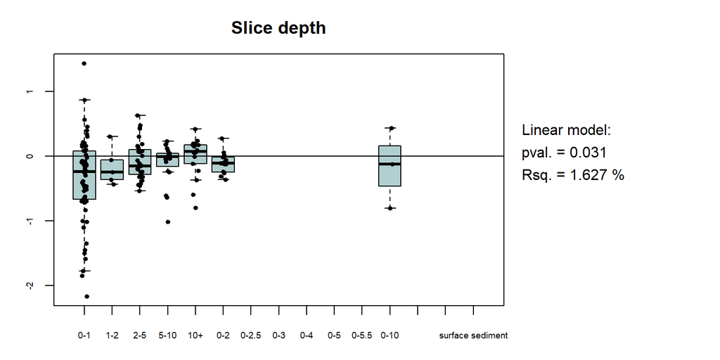

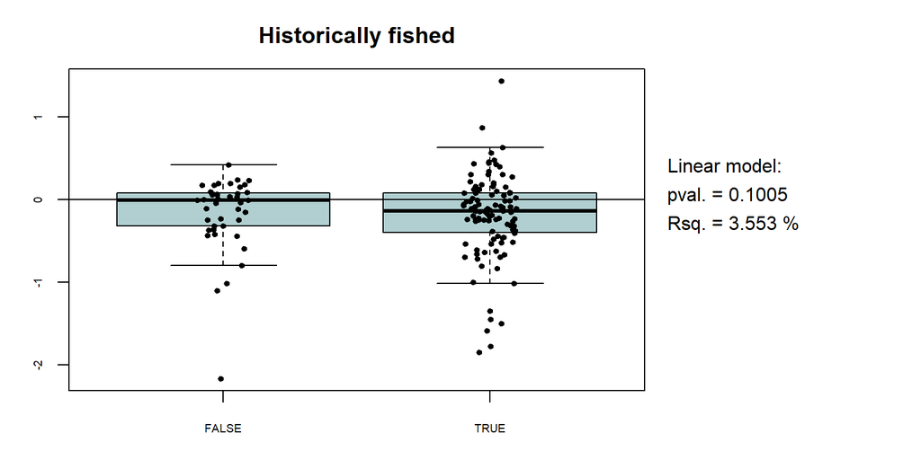

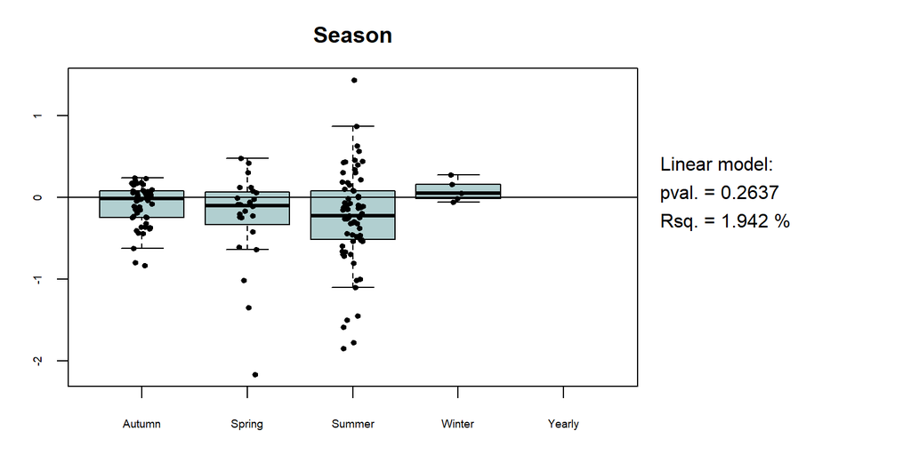

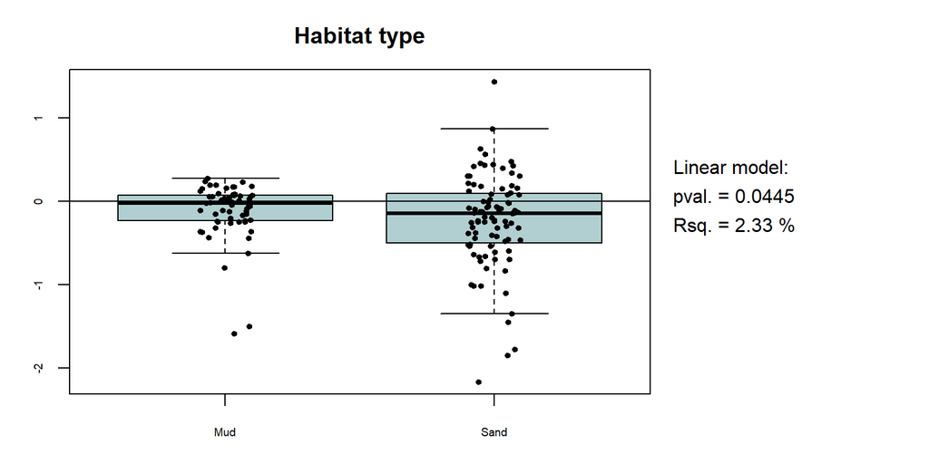